# ME115 - Linguagem R

Tarefa 4

Profas. Samara Kiihl e Tatiana Benaglia

# Manipulação de Dados usando `dplyr`

## Introdução

Usaremos o pacote `dplyr` para manipular efetivamente e calcular estatísticas sumárias sobre subconjuntos de um conjunto de dados “grande” contendo muitas observações.

### Os dados

Usaremos um conjunto de dados de [expressão gênica](https://pt.wikibooks.org/wiki/Biologia_celular/Expressão_genética) de levedura. Esta é uma versão “limpa” dos dados de expressão gênica de [Brauer et al. Coordination of growth rate, cell cycle, stress response, and metabolic activity in yeast. (2008) Mol Biol Cell 19: 352-367](https://www.ncbi.nlm.nih.gov/pubmed/17959824).

Esses dados são de um [microarranjo de expressão gênica](https://www.youtube.com/watch?v=0ATUjAxNf6U), e neste artigo os autores estão examinando a relação entre taxa de crescimento e expressão gênica em culturas de leveduras limitadas por um entre seis nutrientes diferentes: glicose, leucina, amônio, sulfato, fosfato e uracila. Se você propiciar à levedura um meio rico em nutrientes, exceto restringir o fornecimento de um único nutriente, poderá controlar a taxa de crescimento a qualquer taxa que escolher. Com a falta de nutrientes específicos, você pode encontrar genes na levedura que:

1. **Aumentam ou diminuem sua expressão em resposta à taxa de crescimento**. Os padrões de expressão dependentes da taxa de crescimento podem nos dizer muito sobre o controle do ciclo celular e como a célula responde ao estresse. Os autores descobriram que a expressão de $>25\%$ de todos os genes de levedura está linearmente correlacionada com a taxa de crescimento, independente do nutriente limitante. Eles também descobriram que o subconjunto de genes correlacionados negativamente ao crescimento é enriquecido para funções peroxissomais, e genes positivamente correlacionados codificam principalmente funções ribossômicas.
2. **Respondam de forma diferente quando diferentes nutrientes estão sendo limitados**. Se você vir genes específicos que respondem de maneira muito diferente quando um nutriente é fortemente restrito, esses genes podem estar envolvidos no transporte ou no metabolismo desse nutriente específico.

Você pode baixar a versão já processada dos dados no arquivo chamado brauer2007_tidy.csv (link ou anexo).

## Leitura dos Dados

Carregue os pacotes `dplyr` e `readr` para ler e exibir esses dados de maneira mais eficiente. Use a função `read_csv()` do pacote `readr` para ler os dados e salve num objeto.

```r
# Carregar pacotes
library(readr)
library(dplyr)

# Leitura dos dados
ydat <- read_csv(file="dados/brauer2007_tidy.csv")
```

Para visualizar os dados, veja as opções abaixo:

```r
# Visualizar os dados
ydat

# Semelhante ao str()
glimpse(ydat)

# Opcionalmente, visualize os dados numa janela nova
View(ydat)
```

Quando você lê os dados com o pacote readr (usando a função `read_csv()`) e já estava com o pacote `dplyr` carregado, o objeto salvo assume essa classe “especial” de data frames chamada `tbl` (tibble). Esse tipo de objeto facilita o uso do pacote `dplyr`, principalmente quando estamos trabalhando com grandes bancos de dados. Verifique a classe do objeto salvo usando o comando:

```r
class(ydat)
```

O pacote `dplyr` oferece vários verbos úteis para o gerenciamento de dados que vocês aprenderam no tutorial do DataCamp. Sozinhos eles não fazem nada que a base R não possa fazer. Aqui estão alguns dos verbos com os quais trabalharemos nesta lição:

- filter()
- select()
- mutate()
- arrange()
- summarize()
- group_by()

Todos usam um `data.frame` ou `tbl_df` como entrada para o primeiro argumento e retornam um `data.frame` ou `tbl_df` como saída.

## Exercícios

1. Selecione os dados onde o processo biológico da ontologia genética (a variável `bp`) é a “biossíntese de leucina” (leucine biosynthesis) e o nutriente limitante foi a Leucina (Leucine). Armazene sua resposta em um novo dataframe `leudat`, que deve ser um dataframe de 24 x 7. Quantos genes resultantes e quantas taxas de crescimento distintas temos nessa seleção?

   ```r
   leudat <- filter()
   ```

2. Use `arrange()` no resultado acima para organizar os dados por gene e taxa de crescimento.

   ```r
   arrange()
   ```

3. Considerando os dados originais `ydat`, use o verbo `summarize()` para obter as seguintes estatísticas:
   - nobs: o número de observações
   - ngenes: o número de genes distintos (`symbol`)
   - meanexp: a expressão média para todos os genes
   - r: correlação entre taxa e expressão (`rate` e `expression`)

   ```r
   summarize(ydat,           )
   ```

4. Crie um novo objeto chamado `nogo` que não contenha as anotações GO (colunas `bp` e `mf`).

   ```r
   # crie um novo conjunto de dados sem as anotações go.
   nogo <- select()
   ```

   Veja como os dados originais `ydat` estão inalterados. Mude para eval=TRUE`.

   ```r
   ydat
   ```

5. O nível de expressão relatado aqui é o $log_2$ do sinal da amostra dividido pelo sinal no canal de referência. Para os dados `nogo`, usando (`mutate()`), adicione uma nova variável chamada `signal`, que é a taxa real do sinal bruto em vez do sinal transformado em log.

   ```r
   mutate()
   ```

6. O `mutate()` também tem um pequeno recurso interessante, pois é “preguiçoso”. Você pode alterar e adicionar uma variável e, em seguida, continuar a mutação para adicionar mais variáveis com base nessa variável que você acabou de adicionar no mesmo comando. Então, repita o comando acima, mas agora crie também uma outra coluna chamada `sigsr` que seja a raiz quadrada da relação do sinal.

   ```r
   nogo <- mutate()
   ```

   Veja os gráficos a seguir (não se preocupe com os detalhes do código ainda, pois estudaremos isso futuramente). Por que você acha que os dados foram transformados antes da análise?

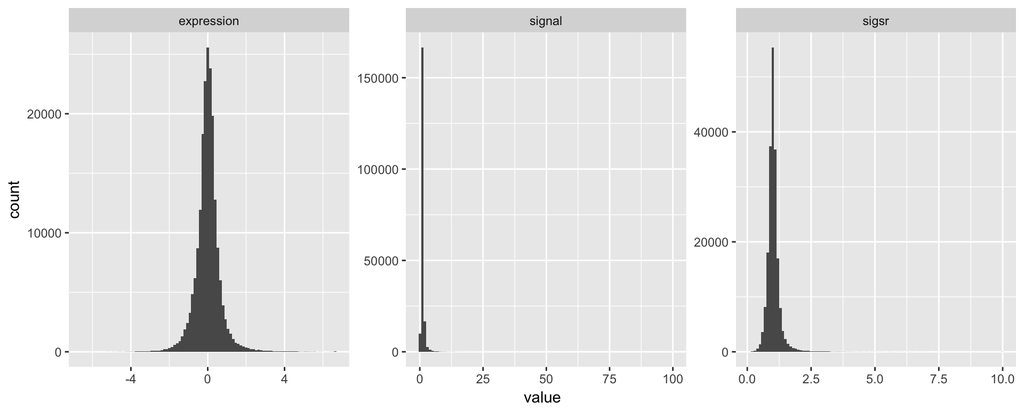

7. Suponha que quiséssemos obter a correlação entre a taxa de crescimento e expressão separadamente para cada nutriente limitante apenas para genes na via de biossíntese de leucina e retornar uma lista ordenada desses coeficientes de correlação arredondados para dois dígitos? Mentalmente faríamos algo assim:
   - Pegue o conjunto de dados ydat
   - então filter() para genes na via de biossíntese de leucina
   - então group_by() o nutriente limitante
   - então summarize() para obter a correlação ( cor() ) entre taxa e expressão
   - então mutate() para arredondar o resultado do cálculo acima para dois dígitos significativos
   - então arrange() pelo coeficiente de correlação arredondado acima

   Isso é executado pelo seguinte código:

   ```r
   arrange(
     mutate(
       summarize(
         group_by(
           filter(ydat, bp=="leucine biosynthesis"),
           nutrient),
       r=cor(rate, expression)),
     r=round(r, 2)),
   r)
   ```

   ```
   ## # A tibble: 6 x 2
   ##    nutrient     r
   ##       <chr> <dbl>
   ## 1   Leucine -0.58
   ## 2   Glucose -0.04
   ## 3   Ammonia  0.16
   ## 4   Sulfate  0.33
   ## 5 Phosphate  0.44
   ## 6    Uracil  0.58
   ```

   O código pode ficar muito mais elegante usando `%>%`! Reescreva o código acima usando pipe. Basicamente você deve trocar todos os “então” da descrição do problema pelo simbolo `%>%`.

   ```r
   ## Complete o código abaixo
   ydat %>%
       filter() ...
   ```

8. Mostre os nutrientes e valores de expressão para o gene ADH2 quando a taxa de crescimento é restrita a 0.05. **Dica:** 2 pipes: `filter()` e `select()`.
9. Quais são os quatro genes mais expressos quando a taxa de crescimento é restrita a 0.05 restringindo a glicose? Mostrar apenas o símbolo, o valor da expressão e os termos GO. **Dica:** 4 pipes: `filter()`, `arrange()`, `filter()` e `select()`.
10. Quando a taxa de crescimento é restrita a 0.05, qual é o nível médio de expressão em todos os genes no processo biológico de “resposta ao estresse” (response to stress), separadamente para cada nutriente limitante? E quanto aos genes no processo biológico da “biossíntese de proteínas” (protein biosynthesis)? **Dica:** 3 pipes: `filter()`, `group_by()`, `summarize()`.